# DES_part3_03679401

- 3 - Generating Random Numbers:
- 3.1 Implementation:

```python
%matplotlib inline
import matplotlib
import numpy as np
import matplotlib.pyplot as plt
import pylab
```

- Task 3.2.1: Verification of distributions:

If ρ = 0.01, We plot the PDF of an exponential distribution (mean = 1s = 1000ms) for the inter arrival time distribution and the PDF of an exponential distribution (mean = λ/ρ = 10ms) for the serving time distribution). We plot also a histogram for a uniform distribution ( a = 2 and b = 4 ). So, we obtained these three PDFs.

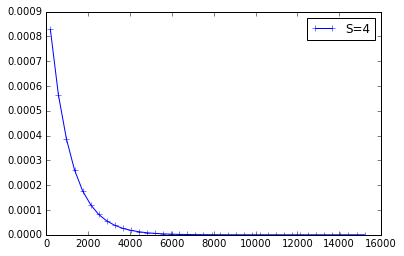

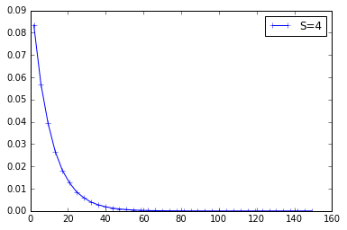

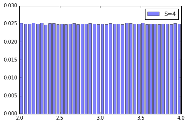

```python
import part3_simstudy
%matplotlib inline
part3_simstudy.task_3_2_1()
```

- Task 3.2.2: Verification of system utilization:

We run the tests of this third part.

```python
import part3_tests
%run part3_tests
```

```
.
----------------------------------------------------------------------
Ran 1 test in 2.291s

OK
```

we verify the implementation of the system utilization by simulating an M/M/1/S system with a limited queue capacity (S = 5) and ρ = λ/μ = 0.01, 0.5, 0.8, 0.9. We simulate the system for 100s and 1000s. So, we obtained:

```python
part3_simstudy.task_3_2_2()
```

```
The system utilization results for a simulation time of 100s :
[0.012082482767241845, 0.597395559857782, 0.8377834646904163, 0.8777644954422696]
The system utilization results for a simulation time of 1000s :
[0.009844090114910428, 0.49085651231446564, 0.7345679741191304, 0.8032662811920217]
```

- 3.3 Analysis and General Questions:
- Task 3.3.1: Seed for Random Number Generation:

In non-deterministic simulation using sampling like what we are doing many time in this project, a random number seed is required so that we can reproduce precisely the same sequence of random numbers for tha same distribution in order to make a verification and a validation for our system. What was used in the tests of the first and the second part to verify the number of dropped packets is an accurate example for the use of the seed in non-deterministic systems.

- Task 3.3.2: Bins for Histograms:

As it was explained in the previous part, we can use the method of "Thumbs" in order to choose the number of bins. In fact, if we choose a very high number of bins, we will see many peaks but we can't notice the correct distribution, however When choosing a very little number of bins, our distribution will tend to be uniform, such that we can't notice the differences between the curves either. So, it is important to choose the right number of bins in order to draw the right conclusions from the plots (here we used 40 bins to plot our distributions) and we notice that the number of bins should increase when the number of samples increases.

- Task 3.3.3: System Utilization: